# Topic 6 Exercises: Selecting Model Terms

# 6.8.1

# a

Best subset, because this model analyses every possible combination of predictors while the other methods ‘build’ a model based on the previous iteration.

# b

Best subset will most likely have the smallest test RSS for similar reasoning as in part a.

# c

1. T, the k+1-variable model is built from the k-variable model with the addition of another predictor
2. T, the k-vairable model is made from the exclusion of a predictor from the k+1-variable model
3. F, because these models are build from p or 1 predictors they may come to different conclusions about which predictors are significant
4. F, same as c-iii.
5. F, best subset analyses all combinations of predictors for different # of variables and between two models certain predictos may be ‘swapped’.

# 6.8.2

# a

3. similar to ridge regression, lasso method produces a less flexible model with decreased variance, just with fewer predictors

# b

3. ridge regression is less flexible and able to geratly decrease variance with little bias increase.

# c

2. non-linear methods are able to ‘follow’ the data more closely than least squares but becasue of this they are likely to have high variance.

# 6.8.9

# a

```r
#College=read.csv("/home/local/MAC/molson6/Math 253 Assignments SSH/College.csv")
library(ISLR)
train=sample(1:dim(College)[1],(dim(College)[1]/2))
test=-train
College.train=College[train,]
College.test=College[test,]
```

# b

```r
lm.fit=lm(Apps~., data=College.train[,-1])
lm.pred=predict(lm.fit, College.test)
mean((College.test[,"Apps"] - lm.pred)^2)
```

```
## [1] 966993.1
```

# c

```r
library(glmnet)
```

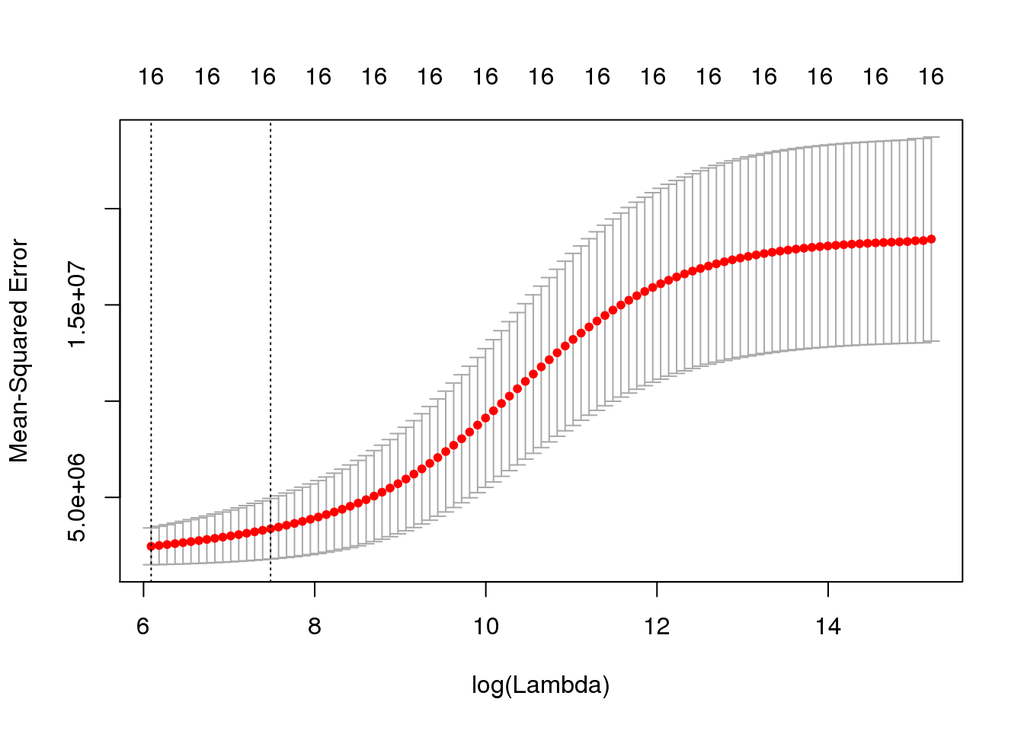

```r
x=model.matrix(Apps~., College[,-1])
y=College$Apps
grid=10^seq(10,-2,length=100)
ridge.mod=glmnet(x,y,alpha=0,lambda=grid)
Apps.test=College$Apps[test]
ridge.mod=glmnet(x[train,], y[train], alpha=0, lambda=grid, thresh=1e-12)
set.seed(1)
cv.out=cv.glmnet(x[train,],y[train], alpha=0)
plot(cv.out)
```

```r
bestlam=cv.out$lambda.min
bestlam
```

```
## [1] 440.9231
```

```r
ridge.pred=predict(ridge.mod,s=bestlam,newx=x[test,])
mean((ridge.pred-Apps.test)^2)
```

```
## [1] 786250.6
```

```r
out=glmnet(x,y,alpha=0)
predict(out,type="coefficients",s=bestlam)[1:19]
```

```
##  [1] -2.035507e+03  0.000000e+00  9.563975e-01  5.267078e-01  2.393877e+01
##  [6]  1.478308e+00  9.052090e-02  3.397781e-02 -3.787941e-02  1.803794e-01
## [11]  1.150179e-01 -4.169278e-03 -1.676762e+00 -2.685588e+00  2.059213e+01
## [16] -1.077077e+01  7.646298e-02  1.059087e+01            NA
```

# d

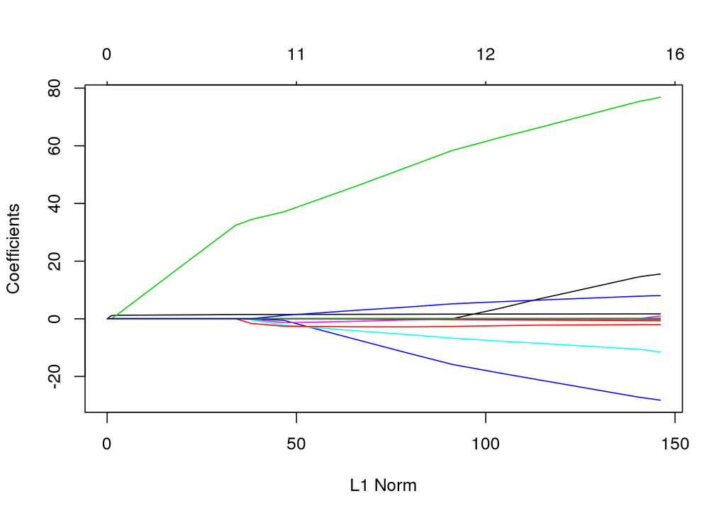

```r
lasso.mod=glmnet(x[train,],y[train],alpha = 1,lambda = grid)
plot(lasso.mod)
```

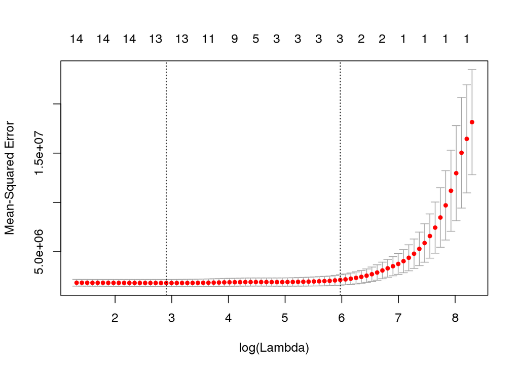

```r
set.seed(1)
cv.out=cv.glmnet(x[train,], y[train],alpha=1)
plot(cv.out)
```

```r
bestlam=cv.out$lambda.min
lasso.pred=predict(lasso.mod,s=bestlam,newx=x[test,])
mean((lasso.pred-Apps.test)^2)
```

```
## [1] 905240.7
```

```r
out=glmnet(x,y,alpha=1,lambda=grid)
lasso.coef=predict(out, type="coefficients",s=bestlam)[1:18,]
lasso.coef
```

```
##   (Intercept)   (Intercept)        Accept        Enroll     Top10perc
## -1.000393e+03  0.000000e+00  1.480864e+00 -2.109496e-01  3.588124e+01
##     Top25perc   F.Undergrad   P.Undergrad      Outstate    Room.Board
## -4.130290e+00  0.000000e+00  3.516224e-02 -8.445281e-02  1.148971e-01
##         Books      Personal           PhD      Terminal     S.F.Ratio
##  0.000000e+00  4.659280e-03 -4.327475e+00 -1.424785e+00  1.340077e+01
##   perc.alumni        Expend     Grad.Rate
## -2.121346e+00  7.452112e-02  5.054892e+00
```

# e

```r
library(pls)
```

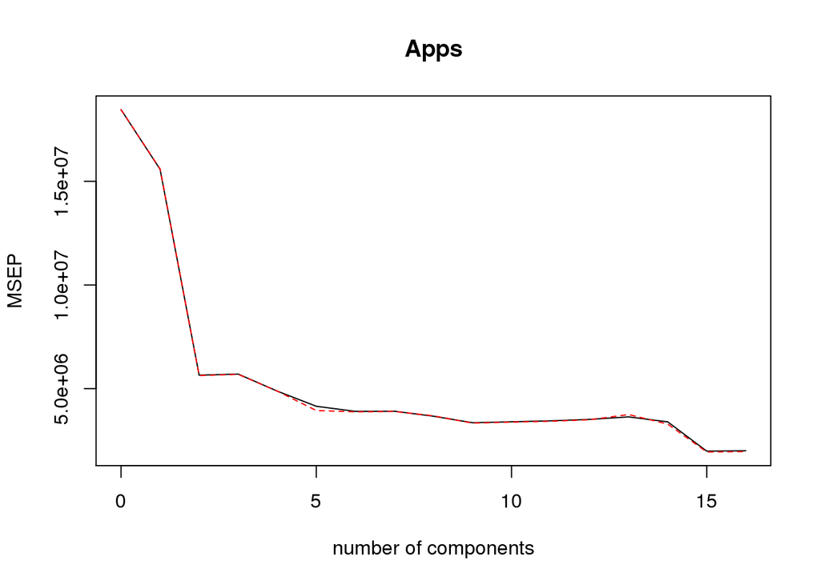

```r
set.seed(1)
pcr.fit=pcr(Apps~., data=College[,-1],subset=train,scale=TRUE, validation="CV")

validationplot(pcr.fit,val.type = "MSEP")
```

```r
summary(pcr.fit)
```

```
## Data:    X dimension: 388 16
##  Y dimension: 388 1
## Fit method: svdpc
## Number of components considered: 16
##
## VALIDATION: RMSEP
## Cross-validated using 10 random segments.
##        (Intercept)  1 comps  2 comps  3 comps  4 comps  5 comps  6 comps
## CV            4296     3947     2377     2388     2209     2037     1976
## adjCV         4296     3949     2373     2385     2209     1986     1970
##        7 comps  8 comps  9 comps  10 comps  11 comps  12 comps  13 comps
## CV        1978     1916     1832      1844      1857      1875      1907
## adjCV     1975     1920     1827      1840      1851      1870      1937
##        14 comps  15 comps  16 comps
## CV         1843      1409      1416
## adjCV      1814      1395      1401
##
## TRAINING: % variance explained
##       1 comps  2 comps  3 comps  4 comps  5 comps  6 comps  7 comps
## X       32.25    56.38    64.20    70.79    76.30    81.62    85.43
## Apps    15.13    70.47    70.48    74.78    80.12    80.19    80.47
##       8 comps  9 comps  10 comps  11 comps  12 comps  13 comps  14 comps
## X       88.76    91.94     94.22     96.18     97.41     98.42     99.28
## Apps    81.22    83.06     83.06     83.14     83.29     83.34     89.39
##       15 comps  16 comps
## X        99.80    100.00
## Apps     92.42     92.52
```

```r
pcr.pred=predict(pcr.fit,x[test,-1],ncomp=9)
mean((pcr.pred-Apps.test)^2)
```

```
## [1] 1390422
```

# f

```r
set.seed(1)
pls.fit=plsr(Apps~.,data=College[,-1], subset=train, scale=TRUE,validation="CV")
summary(pls.fit)
```

```
## Data:    X dimension: 388 16
##  Y dimension: 388 1
## Fit method: kernelpls
## Number of components considered: 16
##
## VALIDATION: RMSEP
## Cross-validated using 10 random segments.
##        (Intercept)  1 comps  2 comps  3 comps  4 comps  5 comps  6 comps
## CV            4296     2257     2022     1763     1710     1556     1454
## adjCV         4296     2250     2018     1753     1686     1532     1435
##        7 comps  8 comps  9 comps  10 comps  11 comps  12 comps  13 comps
## CV        1428     1410     1406      1413      1414      1416      1417
## adjCV     1412     1396     1392      1398      1400      1401      1402
##        14 comps  15 comps  16 comps
## CV         1417      1416      1416
## adjCV      1402      1401      1401
##
## TRAINING: % variance explained
##       1 comps  2 comps  3 comps  4 comps  5 comps  6 comps  7 comps
## X       26.63    51.83    61.88    65.04    68.58    72.61    77.91
## Apps    74.52    80.05    86.09    90.00    91.87    92.31    92.39
##       8 comps  9 comps  10 comps  11 comps  12 comps  13 comps  14 comps
## X       81.32    84.29     86.61     90.12     92.51     94.65     96.71
## Apps    92.48    92.51     92.51     92.52     92.52     92.52     92.52
##       15 comps  16 comps
## X        98.72    100.00
## Apps     92.52     92.52
```

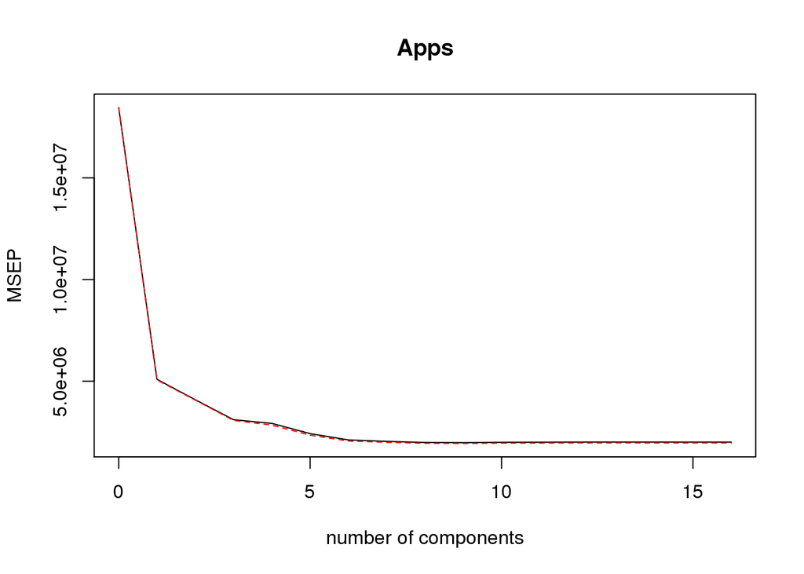

```r
validationplot(pls.fit,val.type = "MSEP")
```

```r
pls.pred=predict(pls.fit,x[test,-1],ncomp=5)
mean((pls.pred-Apps.test)^2)
```

```
## [1] 962121.7
```

# g